# Manuals

Links and guide to some relevant manuals

*Last Updated 2025-06-02*

Ideally, this page will just link directly to the [IOP Seaglider resources page](https://iop.apl.washington.edu/iopsg/).

But for now, some potentially useful files are linked here/included in this repository.

Copies of the files linked below can also be found in the [piloting resources](https://drive.google.com/drive/u/0/folders/1aG8QkLzA80qrKjjVgM2wp6Dndf1uq4Hj) Google Drive Folder.

#### Piloting parameters

Piloting Parameters (Rev B) PDF

Piloting Parameters (Rev E) PDF - Hydroid

[Piloting Parameters (Rev E) - website - seaglider.pub](https://noaaosu.seaglider.pub/parms)

#### File formats

Seaglider File Formats Manual (RevB).pdf

Describes in detail what each line in the .log file means e.g., page 11, lists what each number after `$ERRORS,` means

Errors we see normally:

- 2nd from right, no GPS fix by timeout
- 3rd from right, number of VBD retries
- 4th from right, number of roll retries
- 5th from right, number of pitch retries
- 6th from right, number of VBD errors
- 2nd from left, number of spurious interrupts. Occasional ones are normal

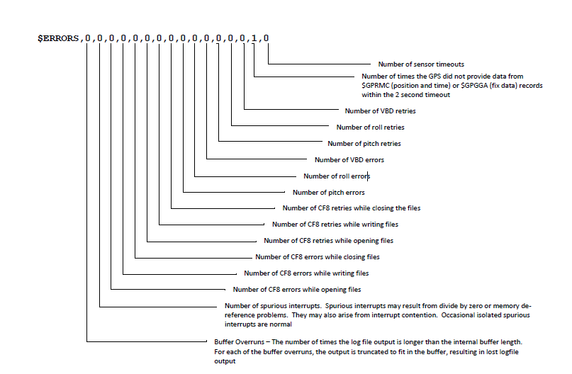

Rev B Errors. Click image to view enlarged version.

SG File Formats (RevE).pdf